# Notebook 18

## Review 1: Calling an API

For this question, you need to make a call to a web-based API that returns data in a JSON format. The data fetches information about popular Beers. The URL has the following elements:

protocol: https authority: api.sampleapis.com path: /beers/stouts query parameters: none (i.e., there are no query parameters)

Below, grab the data from this API using the techniques we learned in class, saving a parsed version of the JSON data as an R object named `obj`.

```r
url_str <- modify_url("https://api.sampleapis.com/beers/stouts")
res <- http_cache_get(url_str, cache_dir = "cache")
obj <- content(res, type = "application/json")
```

## Review 2: Parsing JSON

Create a data tibble in R using the object you produced in the previous question that contains one row for each beer and four columns: the name of the beer, the price of the beer, the average rating, and the number of ratings. Make sure to use appropriate data types (though price will need to be a character value for now). You will want to save the data with a name for use in the next section.

```r
dt <- tibble(
  name = map_chr(obj, ~ .x$name),
  price = map_chr(obj, ~ .x$price),
  review_avg = map_dbl(obj, ~ .x$rating$average),
  review_num = map_int(obj, ~ .x$rating$reviews)
)
dt
```

```
## # A tibble: 117 × 4
##    name                                    price   review_avg review_num
##    <chr>                                   <chr>        <dbl>      <int>
##  1 Founders CBS                            $29.99        1.35        105
##  2 Founders KBS (Kentucky Breakfast Stout) $26.99        3.32        135
##  3 Founders Breakfast Stout                $9.99         4.02        199
##  4 Prairie BOMB!                           $249.99       3.59        288
##  5 Oskar Blues Ten FIDY                    $15.99        1.55        125
##  6 Founders Imperial Stout                 $12.99        1.67        350
##  7 Stone Farking Wheaton w00tstout         $8.99         3.45        435
##  8 Stone Farking Wheaton w00tstout         $18.49        1.71        381
##  9 Stone Xocoveza Mocha Stout              $17.99        4.22        305
## 10 North Coast Old Rasputin Imperial Stout $10.99        1.20        195
## # … with 107 more rows
```

## Review 3: Working with Strings

The price in the data you made in the previous section is not a number but a string because of the dollar sign. Starting with the data in the previous question, use a regular expression to remove the dollar sign and the function as.numeric to create a column called `price_num` that is the price in dollars as a number.

```r
dt %>%
  mutate(price_num = stri_replace_all(price, "", fixed = "$")) %>%
  mutate(price_num = as.numeric(price_num))
```

```
## # A tibble: 117 × 5
##    name                                    price review_avg review_num price_num
##    <chr>                                   <chr>      <dbl>      <int>     <dbl>
##  1 Founders CBS                            $29.…       1.35        105     30.0
##  2 Founders KBS (Kentucky Breakfast Stout) $26.…       3.32        135     27.0
##  3 Founders Breakfast Stout                $9.99       4.02        199      9.99
##  4 Prairie BOMB!                           $249…       3.59        288    250.
##  5 Oskar Blues Ten FIDY                    $15.…       1.55        125     16.0
##  6 Founders Imperial Stout                 $12.…       1.67        350     13.0
##  7 Stone Farking Wheaton w00tstout         $8.99       3.45        435      8.99
##  8 Stone Farking Wheaton w00tstout         $18.…       1.71        381     18.5
##  9 Stone Xocoveza Mocha Stout              $17.…       4.22        305     18.0
## 10 North Coast Old Rasputin Imperial Stout $10.…       1.20        195     11.0
## # … with 107 more rows
```

Now, produce a scatter plot that shows each beer with review average on the x-axis and price (as a number) on the y-axis.

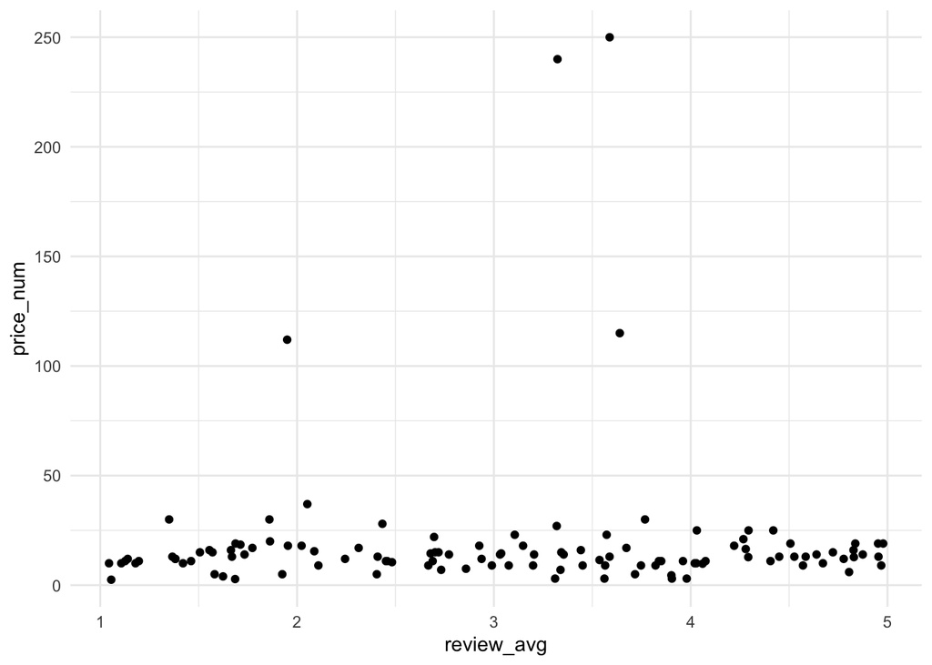

```r
dt %>%
  mutate(price_num = stri_replace_all(price, "", fixed = "$")) %>%
  mutate(price_num = as.numeric(price_num)) %>%
  ggplot(aes(review_avg, price_num)) +
    geom_point()
```

## Review 4: Parsing XML

Below, we read in an XML file taken from the following source (you should take a look as it shows the structure of the file well):

https://teibyexample.org/examples/TBED04v00.htm#shakespeare

```r
sonnet <- read_xml("data/sonnet17.xml")
```

This is a short file, and we will just use it to practice some XPath expressions. Below, grab the text of all of the lines () from the text and store them in a data table with a single column called “line”:

```r
tibble(
  line = xml_text(xml_find_all(sonnet, ".//l"))
)
```

```
## # A tibble: 14 × 1
##    line
##    <chr>
##  1 " Who will believe my verse in time to come,"
##  2 "If it were fill'd with your most high deserts?"
##  3 "Though yet, heaven knows, it is but as a tomb"
##  4 "Which hides your life and shows not half your parts. "
##  5 "If I could write the beauty of  your eyes"
##  6 "And in fresh numbers number all your graces,"
##  7 "The age to come would say ‘This poet lies; "
##  8 "Such heavenly touches ne'er touch'd earthly faces’. "
##  9 "So should my papers, \nyellowed with their age,"
## 10 "Be scorn'd like old men of less truth than tongue; "
## 11 "And your true rights be term' a poet's rage,"
## 12 "And stretched metre of an antique song. "
## 13 "But were some child of yours alive that time,"
## 14 "You should live twice-in it, and in my rhyme. "
```

Now create a data table that has one row for each foot of the poem; include a column called “foot” that contains the text, and columns contained “real” and “met” containing their respective attributes

```r
tibble(
  foot = xml_text(xml_find_all(sonnet, ".//seg[@type='foot']")),
  real = xml_attr(xml_find_all(sonnet, ".//seg[@type='foot']"), "real"),
  met = xml_attr(xml_find_all(sonnet, ".//seg[@type='foot']"), "met"),
)
```

```
## # A tibble: 70 × 3
##    foot           real  met
##    <chr>          <chr> <chr>
##  1 " Who will"    +-    <NA>
##  2 " believe"     <NA>  <NA>
##  3 " my verse"    <NA>  <NA>
##  4 " in time"     <NA>  <NA>
##  5 " to come,"    <NA>  <NA>
##  6 "If it"        <NA>  <NA>
##  7 " were fill'd" <NA>  <NA>
##  8 " with your"   <NA>  <NA>
##  9 " most high"   <NA>  <NA>
## 10 " deserts?"    +-    <NA>
## # … with 60 more rows
```

Now, repeat the previous question but only select those segments that are in the quatrain:

```r
tibble(
  foot = xml_text(xml_find_all(sonnet, ".//lg[@type='quatrain']//seg[@type='foot']")),
  real = xml_attr(xml_find_all(sonnet, ".//lg[@type='quatrain']//seg[@type='foot']"), "real"),
  met = xml_attr(xml_find_all(sonnet, ".//lg[@type='quatrain']//seg[@type='foot']"), "met"),
)
```

```
## # A tibble: 60 × 3
##    foot           real  met
##    <chr>          <chr> <chr>
##  1 " Who will"    +-    <NA>
##  2 " believe"     <NA>  <NA>
##  3 " my verse"    <NA>  <NA>
##  4 " in time"     <NA>  <NA>
##  5 " to come,"    <NA>  <NA>
##  6 "If it"        <NA>  <NA>
##  7 " were fill'd" <NA>  <NA>
##  8 " with your"   <NA>  <NA>
##  9 " most high"   <NA>  <NA>
## 10 " deserts?"    +-    <NA>
## # … with 50 more rows
```

Finally, starting with the data created that has one row for each line, add a column to the data that counts the number of words in each line:

```r
tibble(
  line = xml_text(xml_find_all(sonnet, ".//l"))
) %>%
  mutate(nwords = stri_count(line, regex = "[^ ]+"))
```

```
## # A tibble: 14 × 2
##    line                                                    nwords
##    <chr>                                                    <int>
##  1 " Who will believe my verse in time to come,"                9
##  2 "If it were fill'd with your most high deserts?"             9
##  3 "Though yet, heaven knows, it is but as a tomb"             10
##  4 "Which hides your life and shows not half your parts. "     10
##  5 "If I could write the beauty of  your eyes"                  9
##  6 "And in fresh numbers number all your graces,"               8
##  7 "The age to come would say ‘This poet lies; "                9
##  8 "Such heavenly touches ne'er touch'd earthly faces’. "       7
##  9 "So should my papers, \nyellowed with their age,"            8
## 10 "Be scorn'd like old men of less truth than tongue; "       10
## 11 "And your true rights be term' a poet's rage,"               9
## 12 "And stretched metre of an antique song. "                   7
## 13 "But were some child of yours alive that time,"              9
## 14 "You should live twice-in it, and in my rhyme. "             9
```